# Opinion Formation on the Internet

2019-10-30

# 1 Abstract

Today the majority of people uses online social networks not only to stay in contact with friends, but also find information about relevant topics, or to spread information. While a lot of research has been conducted into opinion formation, only little is known about what influences the spread of information in online social networks. To answer this question, we created an agent-based model and simulated message spreading in social networks using a latent-process model. In our model, we varied four different content types, five different network types, and we varied between a model that also includes a personality model of the agents and a model that did not. We found out, that the network type has only a weak influence on the distribution of content, where the message type and the personality of the user have a clear influence on how many users receive a message.

# 2 Introduction

Social networks such as Facebook, Instagram and Twitter are now integrated into most people’s everyday lives. The users of social networks no longer just use them to keep in touch with friends, but increasingly facilitate social networks to search for information. Besides that, they also form an opinion based on the information and contributions available in social networks. While searching for information and integrating it into their opinion formation, users are no longer just passive recipients of information in online social networks, but are also actively spreading their own opinions (Frees and Koch 2018; Hóllig and Hasebrink 2016; Li et al. 2017). Thus, the dissemination of new information is increasing and a broader range of opinions is voiced (Bakshy et al. 2012).

Social networks play a powerful role and not only influence the formation of opinion of individuals, but can also play a decisive role in political situations and decisions (Guille et al. 2013). It has been shown in the past, that social networks have a great influence on political decisions. One example for this was the American presidential election 2008, where many people saw a great influence of Twitter at the elections (Hughes and Palen 2009).

While the amount of information users receive has changed through social networks, we also have to consider that information can now be individualized through the individual user’s interaction with the network and its structure (DeVito 2017).

On the Internet, users can find almost any information they are looking for. However, the amount of information available on the Internet is now so high that users are no longer able to consume all the information. In addition, users also find contradicting information on the Internet. The increasing availability of information on the Internet has led to the development of recommendation systems (Adomavicius and Tuzhilin 2005). Aiming to make it easier for users to select information, these systems analyse the information available on the Internet, filter it according to specific criteria and provide users with recommendations tailored to their needs (Burke 2002).

Research so far does not tell us much how opinion-forming processes actually take place in social networks and we can’t predict them, let alone their consequences. However, it is very important to consider the impact that the use of social networks has on user opinion formation.

Opinion forming and the processes that influence the formation of opinions have been studied since the 1960s. In the meantime, aspects that were of little or no importance before the rise of the Internet have become relevant for the research of the formation of opinion by individuals. First of all, in social networks every user can express his opinion and reach a large number of other users by just resharing or reposting (Cheng et al. 2014).

By other users reposting the opinion of a user, long cascades are created and the opinion is disseminated (Cheng et al. 2014). Users share information targeting to convince other users of their opinion. Social media simplyfied that users can convey one’s opinion to other individuals

Nevertheless, one aspect that needs to be considered is that users differ in their sharing habits. Lottridge and Bentley investigated the motivation to share contents and the frequency of sharing news on public, social and private platforms. They differentiate between different types of forwarding. Users can share messages with other users, they can share information in a personal message or share information on a social network or public a content publicly. In their research, they found that users have different intentions with different forms of sharing. Users share information publicly, primarily when they want to contribute an ideology. In contrast, they send private messages primarily to tell stories that correspond to their own interests or the context in which the user finds themselves. The first group, sharing news to all channels. So they share both publicly and socially and privately. In contrast, the second group does not share news at all. The last group shares messages to private and social. In keeping with this, they also found that the group that shared the least posts had a negative attitude toward online discussion, whereas the group that shared the most posts had a neutral attitude toward online discussion (Lottridge and Bentley 2018).

In order to understand how the dissemination of information and thus also the formation of opinion in social networks takes place, it is therefore necessary to first consider what motivates users to express their opinion in social media and which personality traits the users have, that publish their opinion in social media. It is further relevant to look at different network structures, as they can also influence to which users a certain content is spread to friends or other users.

# 3 Analysis

Using the agent-based model, we analyzed whether different initial settings lead to different outcomes. As initial configurations, we used different content types (*affective content*, *cognitive content*, *both*, *weak content*) and different network types (*Facebook*, *Barábasi-Albert*, *Watts Strogatz*, *Scale Free Network*, *Random Network*). Further, we compared whether the use of a *personality model* for the creation of the agents in our simulation leads to a different outcome than the simulation runs without the *personality model*. Using these different initial settings, we found the following results.

Our results are depicted in the figure below. It shows for each simulation step how many of the agents who saw the message also forwarded it. The number of forwarding agents is also visible for the five different network types (horizontal); for the agents with and without the use of the *personality model* (vertical); and the different content types (color).

## 3.1 Highest and lowest propoertion of forwarding agents

In contrast, the lowest number of forwarding agents occurred in the simulation, where the content is *weak* or *mostly cognitive*, where the agents are designed according to the *personality model* and where the agents are located in a *Barábasi Albert* network. The agents stop forwarding the message at the latest at the fourth simulation step and until then almost no agent has forwarded the message.

So far we considered, when the proportion of forwarding agents is highest or lowest. Following, we look at the single factors that could have an influence on the proportion of forwarding agents, starting with the content type.

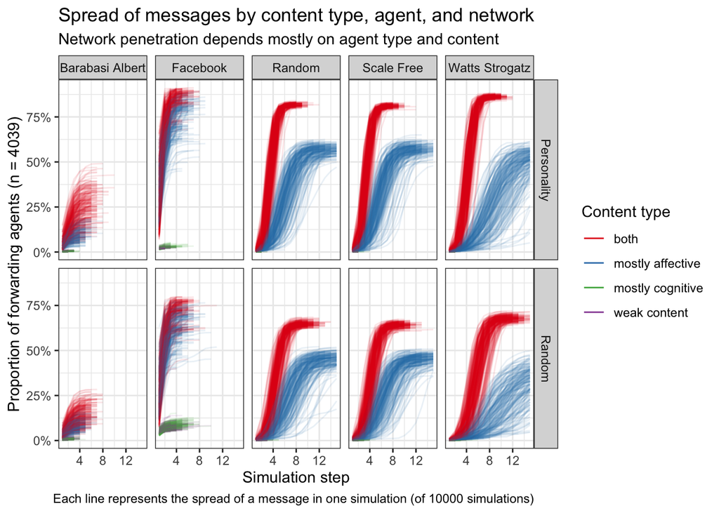

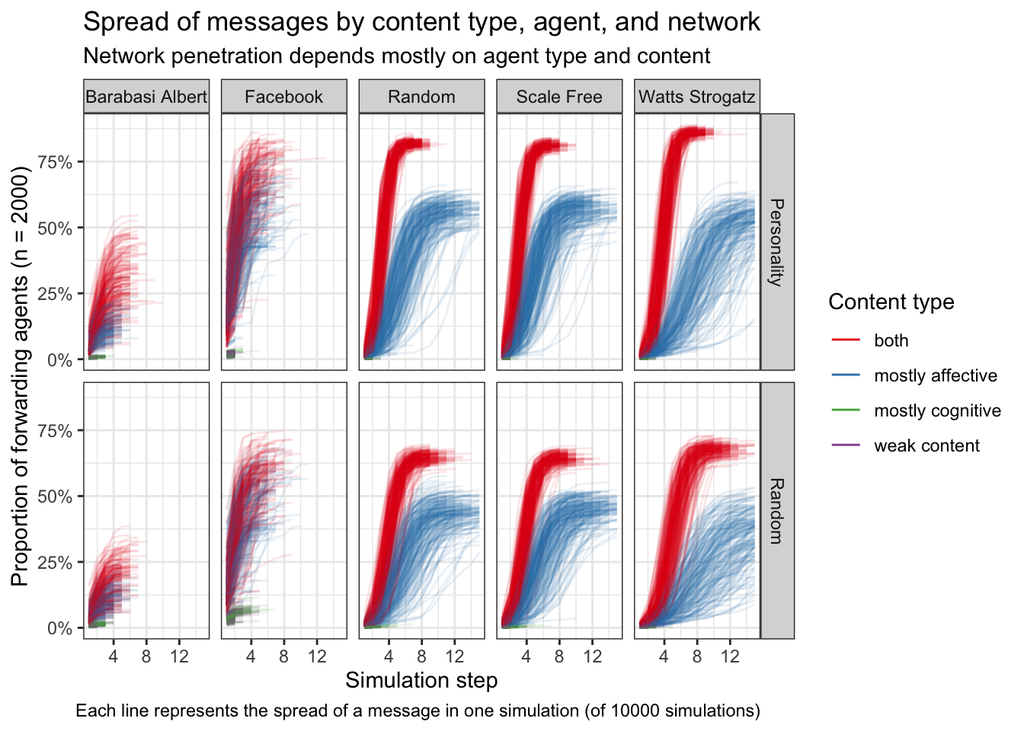

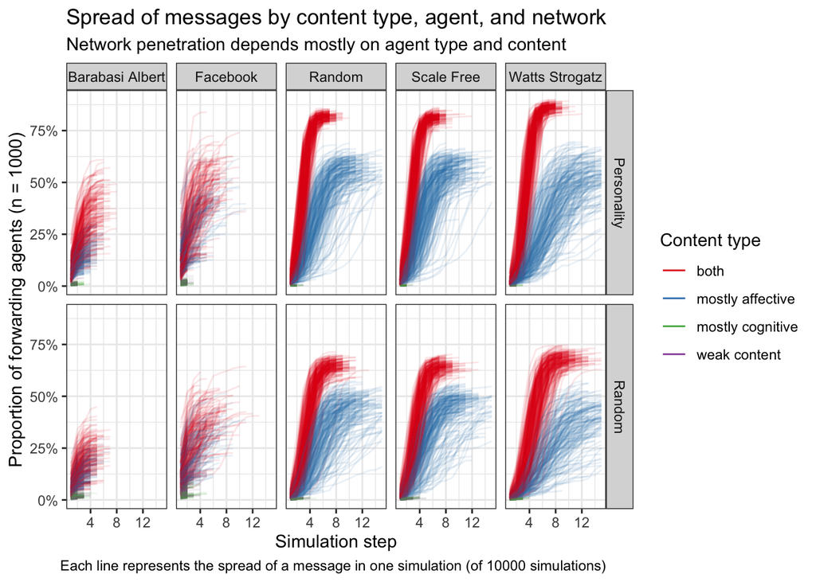

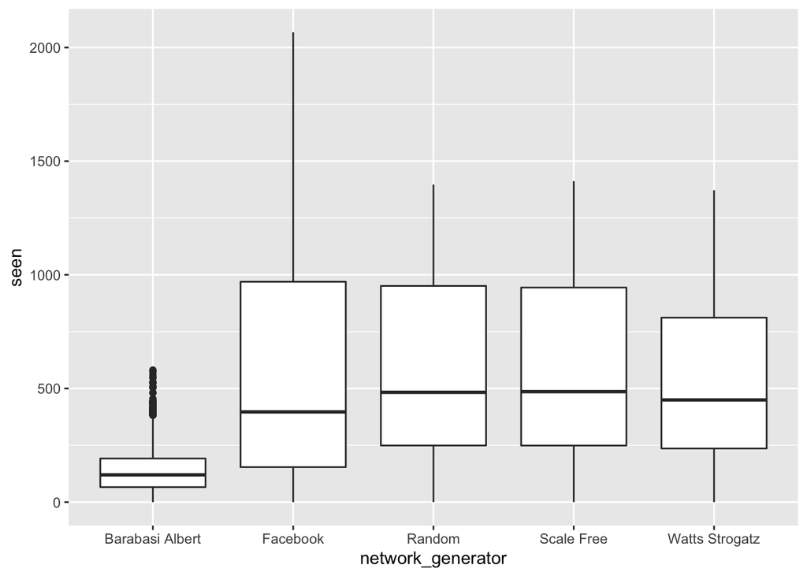

## 3.2 Content types

Comparing the four different contents, most agents forward the content, that is *both* affective and cognitive. Agents forward the *mostly affective* content the second most and significantly more frequently than the other two contents. The *weak content* as well as the *mostly cognitive content* are almost never forwarded at all. The agents also always stop forwarding the message before the eighth simulation step. Only with the *Facebook network* and without using the *personality model*, the *mostly cognitive content* is forwarded somewhat more frequently, but still forwarding does not exceed the eighth step of the simulation.

## 3.3 Network type

After considering the influence of the content type we now look at the different network types and how they influence the number of forwarding agents. As can be seen in the figure of the simulation, the proportion of forwarding agents differs only slightly between the *Random*, *Scale-Free*, and *Watts Strogatz* network. Hardly any difference can be seen between the red and blue lines of the forwarding agents located either in the *Random* or in the *Scale-Free* network. The lines also look very similar for the agents in the *Watts Strogatz* network. While in the *Random* and in the *Scale-Free* network many agents already forward the *both content*, the number of forwarding agents for the *Watts Strogatz* network is a bit higher. If we look at the *mostly affective content*, the number of forwarding agents in the *Watts Strogatz* network differs more for the individual simulations than for the two previously mentioned networks.

Slightly larger differences can be seen for the *Barábasi Albert* and the *Facebook* network. In the *Facebook* and the *Barábasi Albert* network, the number of agents that forward the *both content* and the *mostly affective content* is more similar. In the *Barábasi Albert* network, compared to all other network types, fewer agents forward the two most forwarded contents.

## 3.5 Content, network and personality

Overall, the figure of the simulation shows that the proportion of forwarding agents mostly depends on the *content type* and if the agents have a *personality* designed according to the *personality model* or not. In contrast, the *network type* showed a lower influence except for *Barábasi Albert* and *Facebook* networks.

## 3.6 Correlation of affective and sending individuals

```
[1] 0.3919757
```

## 3.7 Linear model of parameters that play a role

```
Call:
lm(formula = sent ~ affective_value + cognitive_value + agent_count +
    agent_generator + network_generator, data = final_results)

Coefficients:
                    (Intercept)                  affective_value
                     -1543.3160                        1070.6033
                cognitive_value                      agent_count
                       811.3268                           0.2712
          agent_generatorRandom        network_generatorFacebook
                      -190.9290                         526.4487
        network_generatorRandom      network_generatorScale Free
                       571.3076                         568.1528
network_generatorWatts Strogatz
                       553.7441
```

# 4 Used Packages

The following R packages were used:

- Package: knitr by Xie (2019)
- Package: tidyverse by Wickham (2017)
- Package: rmdformats by Barnier (2019)
- Package: DT by Xie, Cheng, and Tan (2018)
- Package: kableExtra by Zhu (2018)
- Package: scales by Wickham (2018)
- Package: psych by Revelle (2018)

# References

Adomavicius, Gediminas, and Alexander Tuzhilin. 2005. “Toward the Next Generation of Recommender Systems: A Survey of the State-of-the-Art and Possible Extensions.” *IEEE Trans. On Knowl. And Data Eng.* 17 (6). Piscataway, NJ, USA: IEEE Educational Activities Department: 734–49. https://doi.org/10.1109/TKDE.2005.99.

Bakshy, Eytan, Itamar Rosenn, Cameron Marlow, and Lada Adamic. 2012. “The Role of Social Networks in Information Diffusion.” In *Proceedings of the 21st International Conference on World Wide Web*, 519–28. WWW ’12. New York, NY, USA: ACM. https://doi.org/10.1145/2187836.2187907.

Barnier, Julien. 2019. *Rmdformats: HTML Output Formats and Templates for ’Rmarkdown’ Documents*. https://CRAN.R-project.org/package=rmdformats.

Burke, Robin. 2002. “Hybrid Recommender Systems: Survey and Experiments.” *User Modeling and User-Adapted Interaction* 12 (4). Hingham, MA, USA: Kluwer Academic Publishers: 331–70. https://doi.org/10.1023/A:1021240730564.

Cheng, Justin, Lada Adamic, P. Alex Dow, Jon Michael Kleinberg, and Jure Leskovec. 2014. “Can Cascades Be Predicted?” In *Proceedings of the 23rd International Conference on World Wide Web*, 925–36. WWW ’14. New York, NY, USA: ACM. https://doi.org/10.1145/2566486.2567997.

DeVito, Michael A. 2017. “From Editors to Algorithms.” *Digital Journalism* 5 (6). Routledge: 753–73. https://doi.org/10.1080/21670811.2016.1178592.

Frees, Beate, and Wolfgang Koch. 2018. “ARD / ZDF-Onlinestudie 2018: Zuwachs Bei Medialer Internetnutzung Und Kommunikation.” *Media Perspektiven* 9: 398–413.

Guille, Adrien, Hakim Hacid, Cecile Favre, and Djamel A. Zighed. 2013. “Information Diffusion in Online Social Networks: A Survey.” *SIGMOD Rec.* 42 (2). New York, NY, USA: ACM: 17–28. https://doi.org/10.1145/2503792.2503797.

Hóllig, Sascha, and Uwe Hasebrink. 2016. “Nachrichtennutzung über Soziale Medien Im Internationalen Vergleich.” *Media Perspektiven* 11: 534–48.

Hughes, A.L., and L. Palen. 2009. “Twitter Adoption and Use in Mass Convergence and Emergency Events.” *International Journal of Emergency Management* 6 (3). Inderscience: 248–60. http://scholar.google.de/scholar.bib?q=info:K5_J-PssizQJ:scholar.google.com/&output=citation&hl=de&as_sdt=0&ct=citation&cd=14.

Li, M., X. Wang, K. Gao, and S. Zhang. 2017. “A Survey on Information Diffusion in Online Social Networks: Models and Methods.” *Information (Switzerland)* 8 (September). https://doi.org/10.3390/info8040118.

Lottridge, Danielle, and Frank R. Bentley. 2018. “Let’s hate together: How people share news in messaging, social, and public networks.” In *Conference on Human Factors in Computing Systems - Proceedings*. Vols. 2018-April. Association for Computing Machinery. https://doi.org/10.1145/3173574.3173634.

Revelle, William. 2018. *Psych: Procedures for Psychological, Psychometric, and Personality Research*. https://CRAN.R-project.org/package=psych.

Stark, Birgit, Melanie Magin, and Pascal Jürgens. 2017. *Ganz Meine Meinung? : Informationsintermediäre Und Meinungsbildung - Eine Mehrmethodenstudie Am Beispiel von Facebook*. 55th ed. Düsseldorf, Germany: Düsseldorf : Landesanstalt für Medien Nordrhein-Westfalen (LfM).

Wickham, Hadley. 2017. *Tidyverse: Easily Install and Load the ’Tidyverse’*. https://CRAN.R-project.org/package=tidyverse.

———. 2018. *Scales: Scale Functions for Visualization*. https://CRAN.R-project.org/package=scales.

Xie, Yihui. 2019. *Knitr: A General-Purpose Package for Dynamic Report Generation in R*. https://CRAN.R-project.org/package=knitr.

Xie, Yihui, Joe Cheng, and Xianying Tan. 2018. *DT: A Wrapper of the Javascript Library ’Datatables’*. https://CRAN.R-project.org/package=DT.

Zhu, Hao. 2018. *KableExtra: Construct Complex Table with ’Kable’ and Pipe Syntax*. https://CRAN.R-project.org/package=kableExtra.